# Building an Understanding of How Nodes in Neural Networks Work

#### Experiment #5 - Evaluate Impacts of Dropout

```python
# Specify attributes about this model
exp_no = 5 # Experiment Number
model_type = 'RNN'
embedding_dim = 50
article_len = 900
mod_layers = 1
layer_type = 'LSTM'
mod_nodes = 64
dropout_rate = [0.1, 0.3, 0.5]
recurrent_dropout_rate = [0.1, 0.3, 0.5]
out_activation = 'softmax'
optimizer = 'rsmprop'
mod_epochs = 10
mod_batch_size = 32
```

```python
# Create lists to hold the results of each iteration.
model_id = 1 # initial model ID
model_id_list = []
model_type_list = []
embedding_dim_list = []
article_len_list = []
n_layer_list = []
layer_type_list = []
node_list = []
dropout_rate_list = []
recurrent_dropout_rate_list = []
out_activation_list = []
optimizer_list = []
max_acc_list = []
valid_perform_list = []
epoch_max_list = []
batch_size_list = []
processing_time = []
```

[output not shown]

[output cut: 10 more lines]

[output not shown]

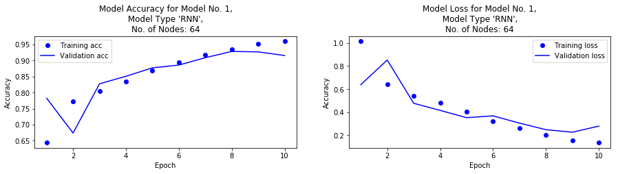

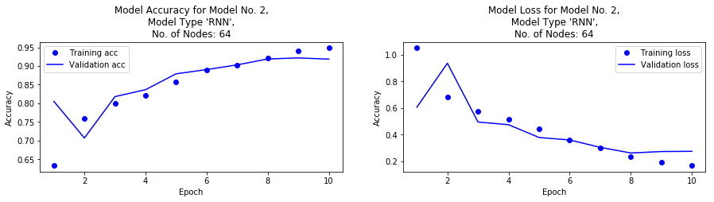

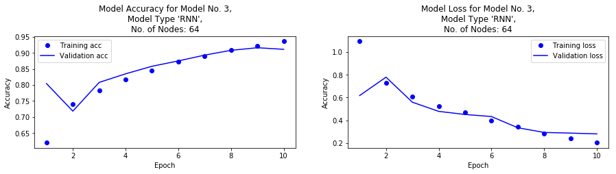

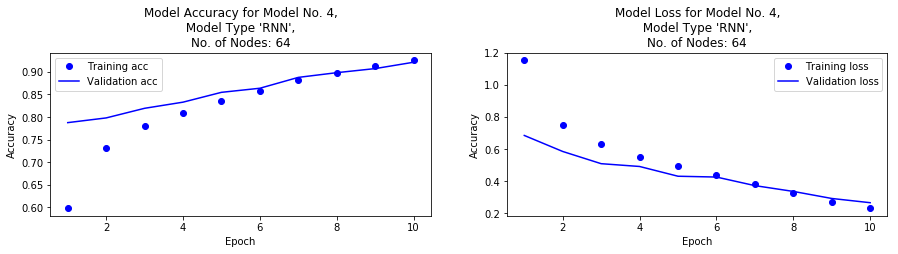

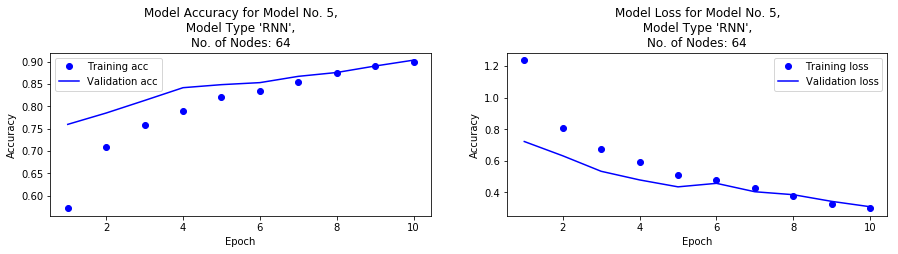

```python
# Create a loop to iterate through model variations
for dropout_rate in dropout_rate:
    for recurrent_dropout_rate in recurrent_dropout_rate:

        # Print the basic parameters of the model being iterated
        print('---------------------------------------------------------------')
        print("Model No.: %r" %model_id)
        print("Model Type: %r" %model_type)
        print("Number of Layers: %r" %mod_layers)
        print("Layer Type: %r" %layer_type)
        print("Dropout Rate: %r" %dropout_rate)
        print("Recurrent Dropout Rate: %r" %recurrent_dropout_rate)
        print("Number of Nodes: %r" %mod_nodes)
        print("Hidden Layer Optimizer: %r" %optimizer)

        start_time = time.clock() # start timer to evaluate how long it takes to train this base model

        # Set seeds for reproducible results
        seed(1)
        set_random_seed(2)
        rn.seed(3)

        # Define the model structure that is to be evaluated.
        model = Sequential()
        model.add(Embedding(input_dim=max_words,
                            output_dim=mod_nodes))
        model.add(LSTM(nodes,
                       dropout=dropout_rate,
                       recurrent_dropout=recurrent_dropout_rate))
        model.add(Dense(9, activation=out_activation))
        #print(model.summary())

        model.compile(optimizer=optimizer,
                      loss='categorical_crossentropy',
                      metrics=['acc'])

        history = model.fit(train_data, train_labels,
                            epochs=mod_epochs,
                            batch_size=mod_batch_size,
                            validation_data=(test_data, test_labels))

        #model.save_weights('pre_trained_glove_model.h5')

        # Stop the timer and append time to list
        end_time = time.clock() # end timer
        runtime = end_time - start_time  # seconds of wall-clock time
        print("\nProcessing time (seconds): %f" % runtime)  # print process time to train model
        processing_time.append(runtime) # append process time results to list for comparison table

        # Identify and print maximum accuracy and epoch where that accuracy was realized
        epoch_max = np.argmax(history.history['acc'])
        acc_max = max(history.history['acc'])
        print('Maxium Accuarcy: %r, Epochs Required to Achieve this Accuracy: %r' %(acc_max, epoch_max))

        # Print validation accuracy
        val_acc_max = max(history.history['val_acc'])
        print("Validation Accuracy: %r" %val_acc_max)

        # Plot the accuracy and loss of each model iteration
        plot_figs(model_id, model_type, mod_nodes)

        # Append lists with values for this model ID
        model_id_list.append(model_id)
        model_type_list.append(model_type)
        embedding_dim_list.append(embedding_dim)
        article_len_list.append(article_len)
        n_layer_list.append(mod_layers)
        layer_type_list.append(layer_type)
        node_list.append(mod_nodes)
        dropout_rate_list.append(dropout_rate)
        recurrent_dropout_rate_list.append(recurrent_dropout_rate)
        out_activation_list.append(out_activation)
        optimizer_list.append(optimizer)
        max_acc_list.append(acc_max)
        valid_perform_list.append(val_acc_max)
        epoch_max_list.append(epoch_max)
        batch_size_list.append(mod_batch_size)

        model_id += 1
```

```python
# round numbers in lists for readability
max_acc_list_formatted = [ '%.3f' % elem for elem in max_acc_list ]
valid_perform_list_formatted = [ '%.3f' % elem for elem in valid_perform_list]
```

```python
# Create a dictionary to store the results of the trained models from code above.
data = OrderedDict([('Model ID', model_id_list),
                    ('Model Type', model_type_list),
                    ('Embedding Dimensions', embedding_dim_list),
                    ('Article Word Length', article_len_list),
                    ('No. of Layers', n_layer_list),
                    ('Layer Type', layer_type_list),
                    ('Nodes', node_list),
                    ('Dropout Rate', dropout_rate_list),
                    ('Recurrent Dropout Rate', recurrent_dropout_rate_list),
                    ('Output Layer Activation', out_activation_list),
                    ('Optimizer', optimizer_list),
                    ('Processing Time', processing_time),
                    ('Maximum Accuracy', max_acc_list_formatted),
                    ('Validation Accuracy', valid_perform_list_formatted),
                    ('No. of Epochs to Max Acc.',epoch_max_list),
                    ('Batch Size', batch_size_list)])
```

```python
# Pickle the data for use in the future without having to run models again.  Write to binary file
file_name = ('Exp_%s_Results.pickle' %exp_no)
with open(file_name, 'wb') as f:
    # Pickle the 'data' dictionary using the highest protocol available.
    pickle.dump(data, f, pickle.HIGHEST_PROTOCOL)

print('\n Run complete. Data objects sent to binary file %r' %file_name)
```

```
 Run complete. Data objects sent to binary file 'Exp_5_Results.pickle'
```

```python
# Extract objects from the dictionary object data
file_name = 'Exp_5_Results.pickle'
pickle_in = open(file_name,"rb")
data = pickle.load(pickle_in)

print('\n Loading of data complete. The binary file %r has been loaded' %file_name)
```

```
 Loading of data complete. The binary file 'Exp_5_Results.pickle' has been loaded
```

```python
# Create a table to display results of this experiment
results = pd.DataFrame(data)
print('\nTable 5: Benchmark Experiment: 1-Layer LSTM RNN Comparing Dropout Rates\n')
results
```

```
Table 5: Benchmark Experiment: 1-Layer LSTM RNN Comparing Dropout Rates
```

|  | Model ID | Model Type | Embedding Dimensions | Article Word Length | No. of Layers | Layer Type | Nodes | Dropout Rate | Recurrent Dropout Rate | Output Layer Activation | Optimizer | Processing Time | Max Train Accuracy | Max Validation Accuracy | No. of Epochs to Max Acc. | Batch Size |
| --- | --- | --- | --- | --- | --- | --- | --- | --- | --- | --- | --- | --- | --- | --- | --- | --- |
| 0 | 1 | RNN | 50 | 900 | 1 | LSTM | 64 | 0.1 | 0.1 | softmax | rmsprop | 2430.117405 | 0.955 | 0.918 | 9 | 32 |
| 1 | 2 | RNN | 50 | 900 | 1 | LSTM | 64 | 0.1 | 0.3 | softmax | rmsprop | 2451.111261 | 0.945 | 0.908 | 9 | 32 |
| 2 | 3 | RNN | 50 | 900 | 1 | LSTM | 64 | 0.1 | 0.5 | softmax | rmsprop | 2444.161164 | 0.936 | 0.907 | 9 | 32 |
| 3 | 4 | RNN | 50 | 900 | 1 | LSTM | 64 | 0.3 | 0.1 | softmax | rmsprop | 2453.271657 | 0.949 | 0.935 | 9 | 32 |
| 4 | 5 | RNN | 50 | 900 | 1 | LSTM | 64 | 0.3 | 0.3 | softmax | rmsprop | 2474.945294 | 0.938 | 0.920 | 9 | 32 |
| 5 | 6 | RNN | 50 | 900 | 1 | LSTM | 64 | 0.3 | 0.5 | softmax | rmsprop | 2430.236333 | 0.928 | 0.911 | 9 | 32 |
| 6 | 7 | RNN | 50 | 900 | 1 | LSTM | 64 | 0.5 | 0.1 | softmax | rmsprop | 2419.573752 | 0.935 | 0.923 | 9 | 32 |
| 7 | 8 | RNN | 50 | 900 | 1 | LSTM | 64 | 0.5 | 0.3 | softmax | rmsprop | 2434.733143 | 0.919 | 0.917 | 9 | 32 |
| 8 | 9 | RNN | 50 | 900 | 1 | LSTM | 64 | 0.5 | 0.5 | softmax | rmsprop | 2447.552985 | 0.904 | 0.895 | 9 | 32 |

#### Experiment #6 - Evaluate Multi-layer RNNs

```python
# Specify attributes about this model
exp_no = 6 # Experiment Number
model_type = 'RNN'
embedding_dim = 50
article_len = 900
mod_layers = 2
layer_type = 'LSTM'
mod_nodes = 64
out_activation = 'softmax'
optimizer = 'rmsprop'
mod_epochs = 10
mod_batch_size = 32
```

```python
# Create lists to hold the results of each iteration.
model_id = 1 # initial model ID
model_id_list = []
model_type_list = []
embedding_dim_list = []
article_len_list = []
n_layer_list = []
layer_type_list = []
node_list = []
out_activation_list = []
optimizer_list = []
max_acc_list = []
valid_perform_list = []
epoch_max_list = []
batch_size_list = []
processing_time = []
```

```
---------------------------------------------------------------
Model No.: 1
Model Type: 'RNN'
Number of Layers: 2
Layer Type: 'LSTM'
Number of Nodes: 64
Hidden Layer Optimizer: 'rmsprop'
Train on 5583 samples, validate on 2208 samples

Processing time (seconds): 4458.372661
Maxium Accuarcy: 0.9690130754181631, Epochs Required to Achieve this Accuracy: 9
Validation Accuracy: 0.9039855072463768
```

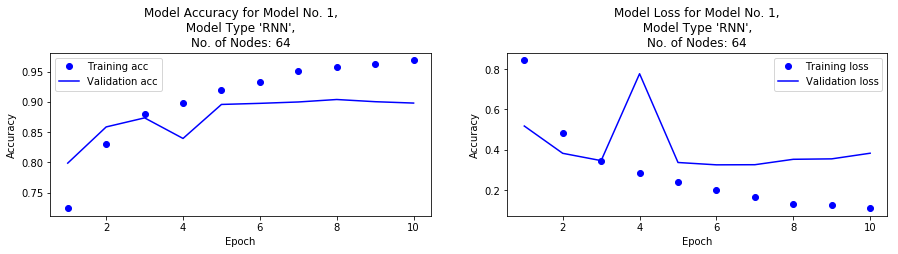

```python
# Create a loop to iterate through model variations


# Print the basic parameters of the model being iterated
print('---------------------------------------------------------------')
print("Model No.: %r" %model_id)
print("Model Type: %r" %model_type)
print("Number of Layers: %r" %mod_layers)
print("Layer Type: %r" %layer_type)
print("Number of Nodes: %r" %mod_nodes)
print("Hidden Layer Optimizer: %r" %optimizer)

start_time = time.clock() # start timer to evaluate how long it takes to train this base model

# Set seeds for reproducible results
seed(1)
set_random_seed(2)
rn.seed(3)

# Define the model structure that is to be evaluated.
model = Sequential()
model.add(Embedding(input_dim=max_words,
                    output_dim=mod_nodes))
model.add(LSTM(mod_nodes, return_sequences=True))
model.add(LSTM(mod_nodes*2))
model.add(Dense(9, activation=out_activation))
#print(model.summary())

model.compile(optimizer=optimizer,
              loss='categorical_crossentropy',
              metrics=['acc'])

history = model.fit(train_data, train_labels,
                    epochs=mod_epochs,
                    batch_size=mod_batch_size,
                    validation_data=(test_data, test_labels))

#model.save_weights('pre_trained_glove_model.h5')

# Stop the timer and append time to list
end_time = time.clock() # end timer
runtime = end_time - start_time  # seconds of wall-clock time
print("\nProcessing time (seconds): %f" % runtime)  # print process time to train model
processing_time.append(runtime) # append process time results to list for comparison table

# Identify and print maximum accuracy and epoch where that accuracy was realized
epoch_max = np.argmax(history.history['acc'])
acc_max = max(history.history['acc'])
print('Maxium Accuarcy: %r, Epochs Required to Achieve this Accuracy: %r' %(acc_max, epoch_max))

# Print validation accuracy
val_acc_max = max(history.history['val_acc'])
print("Validation Accuracy: %r" %val_acc_max)

# Plot the accuracy and loss of each model iteration
plot_figs(model_id, model_type, mod_nodes)

# Append lists with values for this model ID
model_id_list.append(model_id)
model_type_list.append(model_type)
embedding_dim_list.append(embedding_dim)
article_len_list.append(article_len)
n_layer_list.append(mod_layers)
layer_type_list.append(layer_type)
node_list.append(mod_nodes)
out_activation_list.append(out_activation)
optimizer_list.append(optimizer)
max_acc_list.append(acc_max)
valid_perform_list.append(val_acc_max)
epoch_max_list.append(epoch_max)
batch_size_list.append(mod_batch_size)

model_id += 1
```

```python
# round numbers in lists for readability
max_acc_list_formatted = [ '%.3f' % elem for elem in max_acc_list ]
valid_perform_list_formatted = [ '%.3f' % elem for elem in valid_perform_list]
```

```python
# Create a dictionary to store the results of the trained models from code above.
data = OrderedDict([('Model ID', model_id_list),
                    ('Model Type', model_type_list),
                    ('Embedding Dimensions', embedding_dim_list),
                    ('Article Word Length', article_len_list),
                    ('No. of Layers', n_layer_list),
                    ('Layer Type', layer_type_list),
                    ('Nodes', node_list),
                    ('Output Layer Activation', out_activation_list),
                    ('Optimizer', optimizer_list),
                    ('Processing Time', processing_time),
                    ('Maximum Accuracy', max_acc_list_formatted),
                    ('Validation Accuracy', valid_perform_list_formatted),
                    ('No. of Epochs to Max Acc.',epoch_max_list),
                    ('Batch Size', batch_size_list)])
```

```python
# Pickle the data for use in the future without having to run models again.  Write to binary file
file_name = ('Exp_%s_Results.pickle' %exp_no)
with open(file_name, 'wb') as f:
    # Pickle the 'data' dictionary using the highest protocol available.
    pickle.dump(data, f, pickle.HIGHEST_PROTOCOL)

print('\n Run complete. Data objects sent to binary file %r' %file_name)
```

```
 Run complete. Data objects sent to binary file 'Exp_6_Results.pickle'
```

```python
# Extract objects from the dictionary object data
file_name = 'Exp_6_Results.pickle'
pickle_in = open(file_name,"rb")
data = pickle.load(pickle_in)

print('\n Loading of data complete. The binary file %r has been loaded' %file_name)
```

```
 Loading of data complete. The binary file 'Exp_6_Results.pickle' has been loaded
```

```python
# Create a table to display results of this experiment
results = pd.DataFrame(data)
print('\nTable 6: Benchmark Experiment: 2-Layer RNN Model Without Pretrained Embeddings\n')
results
```

```
Table 6: Benchmark Experiment: 2-Layer RNN Model Without Pretrained Embeddings
```

|  | Model ID | Model Type | Embedding Dimensions | Article Word Length | No. of Layers | Layer Type | Nodes | Output Layer Activation | Optimizer | Processing Time | Max Train Accuracy | Max Validation Accuracy | No. of Epochs to Max Acc. | Batch Size |
| --- | --- | --- | --- | --- | --- | --- | --- | --- | --- | --- | --- | --- | --- | --- |
| 0 | 1 | RNN | 50 | 900 | 2 | LSTM | 64 | softmax | rmsprop | 4458.372661 | 0.969 | 0.904 | 9 | 32 |

#### Experiment #7 - Evaluate Impacts of Bidirectional RNN

```python
# Specify attributes about this model
exp_no = 7 # Experiment Number
model_type = 'RNN'
embedding_dim = 50
article_len = 900
mod_layers = 1
layer_type = 'LSTM'
mod_nodes = 64
out_activation = 'softmax'
optimizer = 'rmsprop'
mod_epochs = 10
mod_batch_size = 32
```

```python
# Create lists to hold the results of each iteration.
model_id = 1 # initial model ID
model_id_list = []
model_type_list = []
embedding_dim_list = []
article_len_list = []
n_layer_list = []
layer_type_list = []
node_list = []
out_activation_list = []
optimizer_list = []
max_acc_list = []
valid_perform_list = []
epoch_max_list = []
batch_size_list = []
processing_time = []
```

```
---------------------------------------------------------------
Model No.: 1
Model Type: 'RNN'
Number of Layers: 1
Layer Type: 'LSTM'
Number of Nodes: 64
Hidden Layer Optimizer: 'rmsprop'
Train on 5583 samples, validate on 2208 samples

Processing time (seconds): 4529.568774
Maxium Accuarcy: 0.969192190578542, Epochs Required to Achieve this Accuracy: 9
Validation Accuracy: 0.9329710144927537
```

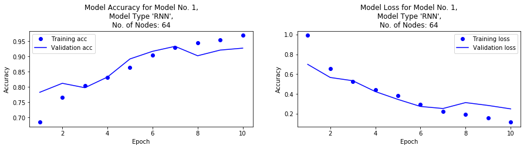

```python
# Create a loop to iterate through model variations


# Print the basic parameters of the model being iterated
print('---------------------------------------------------------------')
print("Model No.: %r" %model_id)
print("Model Type: %r" %model_type)
print("Number of Layers: %r" %mod_layers)
print("Layer Type: %r" %layer_type)
print("Number of Nodes: %r" %mod_nodes)
print("Hidden Layer Optimizer: %r" %optimizer)

start_time = time.clock() # start timer to evaluate how long it takes to train this base model

# Set seeds for reproducible results
seed(1)
set_random_seed(2)
rn.seed(3)

# Define the model structure that is to be evaluated.
model = Sequential()
model.add(Embedding(input_dim=max_words,
                    output_dim=mod_nodes))
model.add(Bidirectional(LSTM(mod_nodes)))
model.add(Dense(9, activation=out_activation))
#print(model.summary())

model.compile(optimizer=optimizer,
              loss='categorical_crossentropy',
              metrics=['acc'])

history = model.fit(train_data, train_labels,
                    epochs=mod_epochs,
                    batch_size=mod_batch_size,
                    validation_data=(test_data, test_labels))

#model.save_weights('pre_trained_glove_model.h5')

# Stop the timer and append time to list
end_time = time.clock() # end timer
runtime = end_time - start_time  # seconds of wall-clock time
print("\nProcessing time (seconds): %f" % runtime)  # print process time to train model
processing_time.append(runtime) # append process time results to list for comparison table

# Identify and print maximum accuracy and epoch where that accuracy was realized
epoch_max = np.argmax(history.history['acc'])
acc_max = max(history.history['acc'])
print('Maxium Accuarcy: %r, Epochs Required to Achieve this Accuracy: %r' %(acc_max, epoch_max))

# Print validation accuracy
val_acc_max = max(history.history['val_acc'])
print("Validation Accuracy: %r" %val_acc_max)

# Plot the accuracy and loss of each model iteration
plot_figs(model_id, model_type, mod_nodes)

# Append lists with values for this model ID
model_id_list.append(model_id)
model_type_list.append(model_type)
embedding_dim_list.append(embedding_dim)
article_len_list.append(article_len)
n_layer_list.append(mod_layers)
layer_type_list.append(layer_type)
node_list.append(mod_nodes)
out_activation_list.append(out_activation)
optimizer_list.append(optimizer)
max_acc_list.append(acc_max)
valid_perform_list.append(val_acc_max)
epoch_max_list.append(epoch_max)
batch_size_list.append(mod_batch_size)

model_id += 1
```

```python
# round numbers in lists for readability
max_acc_list_formatted = [ '%.3f' % elem for elem in max_acc_list ]
valid_perform_list_formatted = [ '%.3f' % elem for elem in valid_perform_list]
```

```python
# Create a dictionary to store the results of the trained models from code above.
data = OrderedDict([('Model ID', model_id_list),
                    ('Model Type', model_type_list),
                    ('Embedding Dimensions', embedding_dim_list),
                    ('Article Word Length', article_len_list),
                    ('No. of Layers', n_layer_list),
                    ('Layer Type', layer_type_list),
                    ('Nodes', node_list),
                    ('Output Layer Activation', out_activation_list),
                    ('Optimizer', optimizer_list),
                    ('Processing Time', processing_time),
                    ('Maximum Accuracy', max_acc_list_formatted),
                    ('Validation Accuracy', valid_perform_list_formatted),
                    ('No. of Epochs to Max Acc.',epoch_max_list),
                    ('Batch Size', batch_size_list)])
```

```python
# Pickle the data for use in the future without having to run models again.  Write to binary file
file_name = ('Exp_%s_Results.pickle' %exp_no)
with open(file_name, 'wb') as f:
    # Pickle the 'data' dictionary using the highest protocol available.
    pickle.dump(data, f, pickle.HIGHEST_PROTOCOL)

print('\n Run complete. Data objects sent to binary file %r' %file_name)
```

```
 Run complete. Data objects sent to binary file 'Exp_7_Results.pickle'
```

```python
# Extract objects from the dictionary object data
file_name = 'Exp_7_Results.pickle'
pickle_in = open(file_name,"rb")
data = pickle.load(pickle_in)

print('\n Loading of data complete. The binary file %r has been loaded' %file_name)
```

```
 Loading of data complete. The binary file 'Exp_7_Results.pickle' has been loaded
```

```python
# Create a table to display results of this experiment
results = pd.DataFrame(data)
print('\nTable 7: Benchmark Experiment: Bidirectional RNN Model Without Pretrained Embeddings\n')
results
```

```
Table 7: Benchmark Experiment: Bidirectional RNN Model Without Pretrained Embeddings
```

|  | Model ID | Model Type | Embedding Dimensions | Article Word Length | No. of Layers | Layer Type | Nodes | Output Layer Activation | Optimizer | Processing Time | Max Train Accuracy | Max Validation Accuracy | No. of Epochs to Max Acc. | Batch Size |
| --- | --- | --- | --- | --- | --- | --- | --- | --- | --- | --- | --- | --- | --- | --- |
| 0 | 1 | RNN | 50 | 900 | 1 | LSTM | 64 | softmax | rmsprop | 4529.568774 | 0.969 | 0.933 | 9 | 32 |

#### Experiment #8 - Compare RNN to 1D CNN

```python
# Specify attributes about this model
exp_no = 8 # Experiment Number
model_type = 'CNN'
embedding_dim = 50
article_len = 900
mod_layers = 1
layer_type = '1D CNN'
mod_nodes = 64
hidden_activation = 'tanh'
out_activation = 'softmax'
optimizer = 'rmsprop'
mod_epochs = 10
mod_batch_size = 32
```

```python
# Create lists to hold the results of each iteration.
model_id = 1 # initial model ID
model_id_list = []
model_type_list = []
embedding_dim_list = []
article_len_list = []
n_layer_list = []
layer_type_list = []
node_list = []
out_activation_list = []
optimizer_list = []
max_acc_list = []
valid_perform_list = []
epoch_max_list = []
batch_size_list = []
processing_time = []
```

```
---------------------------------------------------------------
Model No.: 1
Model Type: 'CNN'
Number of Layers: 1
Layer Type: '1D CNN'
Number of Nodes: 64
Hidden Layer Optimizer: 'rmsprop'
Train on 5583 samples, validate on 2208 samples

Processing time (seconds): 28.936486
Maxium Accuarcy: 0.9971341572631202, Epochs Required to Achieve this Accuracy: 9
Validation Accuracy: 0.9497282608695652
```

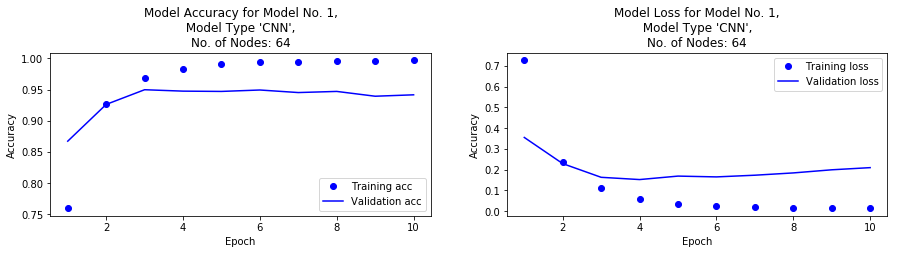

```python
# Create a loop to iterate through model variations


# Print the basic parameters of the model being iterated
print('---------------------------------------------------------------')
print("Model No.: %r" %model_id)
print("Model Type: %r" %model_type)
print("Number of Layers: %r" %mod_layers)
print("Layer Type: %r" %layer_type)
print("Number of Nodes: %r" %mod_nodes)
print("Hidden Layer Optimizer: %r" %optimizer)

start_time = time.clock() # start timer to evaluate how long it takes to train this base model

# Set seeds for reproducible results
seed(1)
set_random_seed(2)
rn.seed(3)

# Define the model structure that is to be evaluated.
model = Sequential()
model.add(Embedding(input_dim=max_words,
                    output_dim=mod_nodes))
model.add(Conv1D(mod_nodes, 7, activation=hidden_activation))
model.add(MaxPooling1D(5))
model.add(Conv1D(mod_nodes, 7, activation=hidden_activation))
model.add(GlobalMaxPooling1D())
model.add(Dense(9, activation=out_activation))
#print(model.summary())

model.compile(optimizer=optimizer,
              loss='categorical_crossentropy',
              metrics=['acc'])

history = model.fit(train_data, train_labels,
                    epochs=mod_epochs,
                    batch_size=mod_batch_size,
                    validation_data=(test_data, test_labels))

#model.save_weights('pre_trained_glove_model.h5')

# Stop the timer and append time to list
end_time = time.clock() # end timer
runtime = end_time - start_time  # seconds of wall-clock time
print("\nProcessing time (seconds): %f" % runtime)  # print process time to train model
processing_time.append(runtime) # append process time results to list for comparison table

# Identify and print maximum accuracy and epoch where that accuracy was realized
epoch_max = np.argmax(history.history['acc'])
acc_max = max(history.history['acc'])
print('Maxium Accuarcy: %r, Epochs Required to Achieve this Accuracy: %r' %(acc_max, epoch_max))

# Print validation accuracy
val_acc_max = max(history.history['val_acc'])
print("Validation Accuracy: %r" %val_acc_max)

# Plot the accuracy and loss of each model iteration
plot_figs(model_id, model_type, mod_nodes)

# Append lists with values for this model ID
model_id_list.append(model_id)
model_type_list.append(model_type)
embedding_dim_list.append(embedding_dim)
article_len_list.append(article_len)
n_layer_list.append(mod_layers)
layer_type_list.append(layer_type)
node_list.append(mod_nodes)
out_activation_list.append(out_activation)
optimizer_list.append(optimizer)
max_acc_list.append(acc_max)
valid_perform_list.append(val_acc_max)
epoch_max_list.append(epoch_max)
batch_size_list.append(mod_batch_size)

model_id += 1
```

```python
# Specify attributes about this model
exp_no = 8 # Experiment Number
model_type = 'CNN + LSTM'
embedding_dim = 50
article_len = 900
mod_layers = 1
layer_type = '1D CNN + LSTM'
mod_nodes = 64
hidden_activation = 'tanh'
out_activation = 'softmax'
optimizer = 'rmsprop'
mod_epochs = 10
mod_batch_size = 32
```

```
---------------------------------------------------------------
Model No.: 2
Model Type: 'CNN + LSTM'
Number of Layers: 1
Layer Type: '1D CNN + LSTM'
Number of Nodes: 64
Hidden Layer Optimizer: 'rmsprop'
Train on 5583 samples, validate on 2208 samples

Processing time (seconds): 465.317844
Maxium Accuarcy: 0.9949847752104604, Epochs Required to Achieve this Accuracy: 8
Validation Accuracy: 0.9451992753623188
```

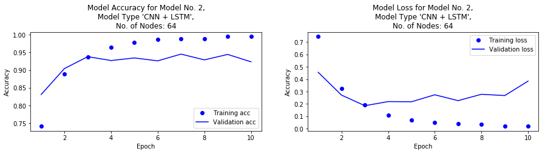

```python
# Create a loop to iterate through model variations


# Print the basic parameters of the model being iterated
print('---------------------------------------------------------------')
print("Model No.: %r" %model_id)
print("Model Type: %r" %model_type)
print("Number of Layers: %r" %mod_layers)
print("Layer Type: %r" %layer_type)
print("Number of Nodes: %r" %mod_nodes)
print("Hidden Layer Optimizer: %r" %optimizer)

start_time = time.clock() # start timer to evaluate how long it takes to train this base model

# Set seeds for reproducible results
seed(1)
set_random_seed(2)
rn.seed(3)

# Define the model structure that is to be evaluated.
model = Sequential()
model.add(Embedding(input_dim=max_words,
                    output_dim=mod_nodes))
model.add(Conv1D(mod_nodes, 7, activation=hidden_activation))
model.add(MaxPooling1D(5))
model.add(Conv1D(mod_nodes, 7, activation=hidden_activation))
model.add(LSTM(mod_nodes))
model.add(Dense(9, activation=out_activation))
#print(model.summary())

model.compile(optimizer=optimizer,
              loss='categorical_crossentropy',
              metrics=['acc'])

history = model.fit(train_data, train_labels,
                    epochs=mod_epochs,
                    batch_size=mod_batch_size,
                    validation_data=(test_data, test_labels))

#model.save_weights('pre_trained_glove_model.h5')

# Stop the timer and append time to list
end_time = time.clock() # end timer
runtime = end_time - start_time  # seconds of wall-clock time
print("\nProcessing time (seconds): %f" % runtime)  # print process time to train model
processing_time.append(runtime) # append process time results to list for comparison table

# Identify and print maximum accuracy and epoch where that accuracy was realized
epoch_max = np.argmax(history.history['acc'])
acc_max = max(history.history['acc'])
print('Maxium Accuarcy: %r, Epochs Required to Achieve this Accuracy: %r' %(acc_max, epoch_max))

# Print validation accuracy
val_acc_max = max(history.history['val_acc'])
print("Validation Accuracy: %r" %val_acc_max)

# Plot the accuracy and loss of each model iteration
plot_figs(model_id, model_type, mod_nodes)

# Append lists with values for this model ID
model_id_list.append(model_id)
model_type_list.append(model_type)
embedding_dim_list.append(embedding_dim)
article_len_list.append(article_len)
n_layer_list.append(mod_layers)
layer_type_list.append(layer_type)
node_list.append(mod_nodes)
out_activation_list.append(out_activation)
optimizer_list.append(optimizer)
max_acc_list.append(acc_max)
valid_perform_list.append(val_acc_max)
epoch_max_list.append(epoch_max)
batch_size_list.append(mod_batch_size)

model_id += 1
```

```python
# round numbers in lists for readability
max_acc_list_formatted = [ '%.3f' % elem for elem in max_acc_list ]
valid_perform_list_formatted = [ '%.3f' % elem for elem in valid_perform_list]
```

```python
# Create a dictionary to store the results of the trained models from code above.
data = OrderedDict([('Model ID', model_id_list),
                    ('Model Type', model_type_list),
                    ('Embedding Dimensions', embedding_dim_list),
                    ('Article Word Length', article_len_list),
                    ('No. of Layers', n_layer_list),
                    ('Layer Type', layer_type_list),
                    ('Nodes', node_list),
                    ('Output Layer Activation', out_activation_list),
                    ('Optimizer', optimizer_list),
                    ('Processing Time', processing_time),
                    ('Maximum Accuracy', max_acc_list_formatted),
                    ('Validation Accuracy', valid_perform_list_formatted),
                    ('No. of Epochs to Max Acc.',epoch_max_list),
                    ('Batch Size', batch_size_list)])
```

```python
# Pickle the data for use in the future without having to run models again.  Write to binary file
file_name = ('Exp_%s_Results.pickle' %exp_no)
with open(file_name, 'wb') as f:
    # Pickle the 'data' dictionary using the highest protocol available.
    pickle.dump(data, f, pickle.HIGHEST_PROTOCOL)

print('\n Run complete. Data objects sent to binary file %r' %file_name)
```

```
 Run complete. Data objects sent to binary file 'Exp_8_Results.pickle'
```

```python
# Extract objects from the dictionary object data
file_name = 'Exp_8_Results.pickle'
pickle_in = open(file_name,"rb")
data = pickle.load(pickle_in)

print('\n Loading of data complete. The binary file %r has been loaded' %file_name)
```

```
 Loading of data complete. The binary file 'Exp_8_Results.pickle' has been loaded
```

```python
# Create a table to display results of this experiment
results = pd.DataFrame(data)
print('\nTable 8: Benchmark Experiment: Comparison of 1D CNN and 1D CNN + LSTM Models\n')
results
```

```
Table 8: Benchmark Experiment: Comparison of 1D CNN and 1D CNN + LSTM Models
```

|  | Model ID | Model Type | Embedding Dimensions | Article Word Length | No. of Layers | Layer Type | Nodes | Output Layer Activation | Optimizer | Processing Time | Max Train Accuracy | Max Validation Accuracy | No. of Epochs to Max Acc. | Batch Size |
| --- | --- | --- | --- | --- | --- | --- | --- | --- | --- | --- | --- | --- | --- | --- |
| 0 | 1 | CNN | 50 | 900 | 1 | 1D CNN | 64 | softmax | rmsprop | 28.936486 | 0.997 | 0.950 | 9 | 32 |
| 1 | 2 | CNN + LSTM | 50 | 900 | 1 | 1D CNN + LSTM | 64 | softmax | rmsprop | 465.317844 | 0.995 | 0.945 | 8 | 32 |

### 5.0 Results

The dataset used for this experiment included 5,583 training articles and 2,208 test articles. The max article length was approximately 900 words, so the training and test tensors were set to have a length of 900 vectors. There were nine categories including trade, ship, acq, earn, money-fx, interest, crude, and money-supply. The data was processed to include only the top 10,000 words, which were tokenized and converted into sequence vectors for use in creating embeddings.

Experiment #3 used two loops to iterate through the number of nodes and several optimizers in a RNN model that used learned word embeddings. The results shown in Table 3 suggest that a simple RNN can be used to predict news article classes with accuracies reaching 0.841. The models with larger numbers of nodes and the RMSProp and Adam optimizers performed the best, with SDG and AdaGrad being quite inferior in performance and training time. Figure 3 shows that significant overfitting is occurring in the model with 64 nodes and the RMSProp optimizer, as training accuracies continue to increase over each epoch while validation accuracy levels off and even drops a bit. The loss graphic in Figure 3 also suggests overfitting with validation loss hitting a minimum and then beginning to increase after approximately 4 epochs. The training time of an RNN is significantly higher than dense networks at approximately 500 seconds.

Experiment #4 compared the basic RNN of the previous example to an LSTM and GRU models, holding all other hyperparameters constant. When compared to the top basic RNN accuracy of 0.841, Table 4 shows the improvement in validation accuracy with both the LSTM and GRU models was substantial, coming in at 0.928 and 0.922 respectively. The cost to achieve these accuracies was training time, as the LSTM and GRU models took approximately 4.4 and 3.4 times longer to train, respectively. Comparing the LSTM and GRU models directly indicates that for approximately the same accuracy, the GRU model trains at about 30% faster. Figures 4 and 5 show the accuracy and loss curves for the LSTM and GRU models, respectively.

While inefficient from a training standpoint, the LSTM network was use for Experiments #5 through #7 to test different configurations of the RNN structure. Table 5 shows the results from including dropout and recurrent dropout in the model, and it can be seen that it does in fact help prevent the model from overfitting. This is shown by the relatively similar training and validation accuracies, as well as a slight improvement in overall generalization on the validation data with a configuration of a 0.3 dropout rate and a 0.1 recurrent dropout rate. Including dropout also increased the training time over the standard LSTM model by approximately 10%. The accuracy and loss curves are included as Figure 6. Experiment #6 considered a multi-layered LSTM model. The results of this experiment are shown in Table 6, and reveal a slight loss in validation accuracy, suggesting information loss may have been experienced by adding additional layers. The accuracy and loss curves for this model are shown in Figure 7. The results of Experiment # 7 which focused on creating a bidirectional LSTM model are included in Table 7. This model was able to slightly outperform the base LSTM model by about 1% but was approximately 107% slower to train. Accuracy and loss curves for this model are included as Figure 8.

The last experiment created a 1-dimensional CNN model to compare to the RNN models trained previously. Additionally, a combination of a LSTM and CNN were developed. Table 8 shows that a 1-dimensional CNN outperforms all RNN models developed, resulting in an accuracy 1.5% higher than any RNN and training in a fraction of the time at approximately 29 seconds. While slightly less accurate than the CNN alone and slower to train, the combination model outperformed all other RNN models in terms of both validation accuracy and training time. The accuracy and loss curves of these two models are shown in Figures 9 and 10.

### 6.0 Conclusions

#### Final Project Results

```python
# Develop list of results from each experiment to tabulate overall findings
exp_list= [1,2,3,4.1,4.2,5,6,7,8.1,8.2]
model_type_list = ['Dense NN', 'Dense NN', 'RNN', 'RNN', 'RNN', 'RNN', 'RNN', 'RNN','CNN', 'CNN + LSTM']
embedding_type_list = ['Learned', 'Pre-Trained','Learned','Learned','Learned','Learned','Learned','Learned','Learned','Learned']
article_len_list = [900]*10
n_layer_list = [1,1,1,1,1,1,2,1,3,3]
layer_type_list = ['Dense','Dense','BasicRNN','LSTM','GRU','LSTM','LSTM','Bidirectional LSTM','1D CNN','1D CNN + LSTM']
node_list = [64, 64, 64, 64, 64, 64, 64, 64, 64, 64]
hidden_activation_list = ['tanh','tanh', 'NA', 'NA', 'NA', 'NA', 'NA', 'NA','tanh','tanh']
dropout_list = ['NA','NA','NA','NA','NA','0.3/0.1','NA', 'NA', 'NA', 'NA']
optimizer_list = ['rsmprop','rsmprop','rsmprop','rsmprop','rsmprop','rsmprop','rsmprop','rsmprop','rsmprop','rsmprop']
processing_time = [18.13, 16.83, 500.87, 2185.90, 1676.76, 2453.27, 4458.37, 4529.57, 28.94, 465.32]
max_acc_list_formatted = [0.998, 0.509, 0.996, 0.974, 0.968, 0.949, 0.969, 0.969, 0.997, 0.995]
valid_perform_list_formatted = [0.942, 0.490, 0.838, 0.928, 0.922, 0.935, 0.904, 0.933, 0.950, 0.945]
epoch_list = [10]*10
batch_size_list = [32]*10
```

```python
data = OrderedDict([('Experiment No.', exp_list),
                    ('Model Type', model_type_list),
                    ('Embedding Type', embedding_type_list),
                    ('Article Word Length', article_len_list),
                    ('No. of Layers', n_layer_list),
                    ('Layer Type', layer_type_list),
                    ('Nodes', node_list),
                    ('Hidden Activation', hidden_activation_list),
                    ('Dropout / Recurrent Dropout Rate', dropout_list),
                    ('Optimizer', optimizer_list),
                    ('Processing Time', processing_time),
                    ('Max Train Accuracy', max_acc_list_formatted),
                    ('Max Validation Accuracy', valid_perform_list_formatted),
                    ('No. of Epochs',epoch_list),
                    ('Batch Size', batch_size_list)])
```

```python
# Create a table to display results of this experiment
results = pd.DataFrame(data)
print('\nTable 9: Final Project Summary Table\n')
results
```

```
Table 9: Final Project Summary Table
```

|  | Experiment No. | Model Type | Embedding Type | Article Word Length | No. of Layers | Layer Type | Nodes | Hidden Activation | Dropout / Recurrent Dropout Rate | Optimizer | Processing Time | Max Train Accuracy | Max Validation Accuracy | No. of Epochs | Batch Size |
| --- | --- | --- | --- | --- | --- | --- | --- | --- | --- | --- | --- | --- | --- | --- | --- |
| 0 | 1.0 | Dense NN | Learned | 900 | 1 | Dense | 64 | tanh | NA | rsmprop | 18.13 | 0.998 | 0.942 | 10 | 32 |
| 1 | 2.0 | Dense NN | Pre-Trained | 900 | 1 | Dense | 64 | tanh | NA | rsmprop | 16.83 | 0.509 | 0.490 | 10 | 32 |
| 2 | 3.0 | RNN | Learned | 900 | 1 | BasicRNN | 64 | NA | NA | rsmprop | 500.87 | 0.996 | 0.838 | 10 | 32 |
| 3 | 4.1 | RNN | Learned | 900 | 1 | LSTM | 64 | NA | NA | rsmprop | 2185.90 | 0.974 | 0.928 | 10 | 32 |
| 4 | 4.2 | RNN | Learned | 900 | 1 | GRU | 64 | NA | NA | rsmprop | 1676.76 | 0.968 | 0.922 | 10 | 32 |
| 5 | 5.0 | RNN | Learned | 900 | 1 | LSTM | 64 | NA | 0.3/0.1 | rsmprop | 2453.27 | 0.949 | 0.935 | 10 | 32 |
| 6 | 6.0 | RNN | Learned | 900 | 2 | LSTM | 64 | NA | NA | rsmprop | 4458.37 | 0.969 | 0.904 | 10 | 32 |
| 7 | 7.0 | RNN | Learned | 900 | 1 | Bidirectional LSTM | 64 | NA | NA | rsmprop | 4529.57 | 0.969 | 0.933 | 10 | 32 |
| 8 | 8.1 | CNN | Learned | 900 | 3 | 1D CNN | 64 | tanh | NA | rsmprop | 28.94 | 0.997 | 0.950 | 10 | 32 |
| 9 | 8.2 | CNN + LSTM | Learned | 900 | 3 | 1D CNN + LSTM | 64 | tanh | NA | rsmprop | 465.32 | 0.995 | 0.945 | 10 | 32 |